# Fungal metagenomes

## Analysis and commands run

### Initial preparation

Upload samples to server:

```bash
rsync --partial --progress W0.tar.bz2 robyn@vulcan.pharmacology.dal.ca:/home/robyn/
rsync --partial --progress W06.tar.bz2 robyn@vulcan.pharmacology.dal.ca:/home/robyn/
rsync --partial --progress W12.tar.bz2 robyn@vulcan.pharmacology.dal.ca:/home/robyn/
```

Unzip and then gzip:

```bash
tar -xf W0.tar.bz2
for i in W0_samples/*.fastq ; do gzip $i ; done

tar -xf W06.tar.bz2
for i in W06_samples/*.fastq ; do gzip $i ; done

tar -xf W12.tar.bz2
for i in W12_samples/*.fastq ; do gzip $i ; done
```

### Kneaddata

**Commands run:**

```bash
parallel -j 1 'kneaddata -i {} -o kneaddata_out_W0/ \
-db /home/shared/bowtiedb/GRCh38_PhiX --trimmomatic /home/robyn/tools/Trimmomatic-0.39/ \
-t 12 --trimmomatic-options "SLIDINGWINDOW:4:20 MINLEN:50" \
--bowtie2-options "--sensitive --dovetail" --remove-intermediate-output' \
 ::: W0_samples/*.fastq.gz
 kneaddata_read_count_table --input kneaddata_out_W0 --output W0_kneaddata_read_counts.txt
 mkdir W0_decontaminated
 for i in kneaddata_out_W0/*kneaddata.fastq ; do mv $i W0_decontaminated ; done

 parallel -j 1 'kneaddata -i {} -o kneaddata_out_W06/ \
-db /home/shared/bowtiedb/GRCh38_PhiX --trimmomatic /home/robyn/tools/Trimmomatic-0.39/ \
-t 12 --trimmomatic-options "SLIDINGWINDOW:4:20 MINLEN:50" \
--bowtie2-options "--sensitive --dovetail" --remove-intermediate-output' \
 ::: W06_samples/*.fastq.gz
 kneaddata_read_count_table --input kneaddata_out_W06 --output W06_kneaddata_read_counts.txt
 mkdir W06_decontaminated
 for i in kneaddata_out_W06/*kneaddata.fastq ; do mv $i W06_decontaminated ; done

 parallel -j 1 'kneaddata -i {} -o kneaddata_out_W12/ \
-db /home/shared/bowtiedb/GRCh38_PhiX --trimmomatic /home/robyn/tools/Trimmomatic-0.39/ \
-t 12 --trimmomatic-options "SLIDINGWINDOW:4:20 MINLEN:50" \
--bowtie2-options "--sensitive --dovetail" --remove-intermediate-output' \
 ::: W12_samples/*.fastq.gz
 kneaddata_read_count_table --input kneaddata_out_W12 --output W12_kneaddata_read_counts.txt
 mkdir W12_decontaminated
 for i in kneaddata_out_W12/*kneaddata.fastq ; do mv $i W12_decontaminated ; done
```

```python
reads_W0  = pd.read_csv('/Users/robynwright/Documents/OneDrive/Langille Lab postdoc/fungal_metagenome/W0_kneaddata_read_counts.txt', header=0, index_col=0, sep='\t')
reads_W06 = pd.read_csv('/Users/robynwright/Documents/OneDrive/Langille Lab postdoc/fungal_metagenome/W06_kneaddata_read_counts.txt', header=0, index_col=0, sep='\t')
reads_W12 = pd.read_csv('/Users/robynwright/Documents/OneDrive/Langille Lab postdoc/fungal_metagenome/W12_kneaddata_read_counts.txt', header=0, index_col=0, sep='\t')

samples = list(reads_W0.index.values)+list(reads_W06.index.values)+list(reads_W12.index.values)

for s in range(len(samples)):
  samples[s] = samples[s].split('-')[0]
all_samples = sorted(list(set(samples)))
pltx = {}
all_x = []
for s in range(len(all_samples)):
  pltx[all_samples[s]] = s
  all_x.append(s)
```

**W0 percent reads kept:**

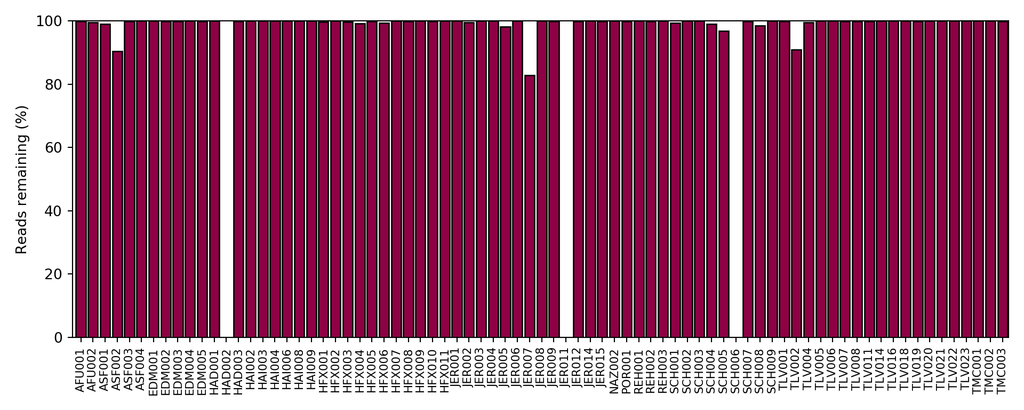

**W06 percent reads kept:**

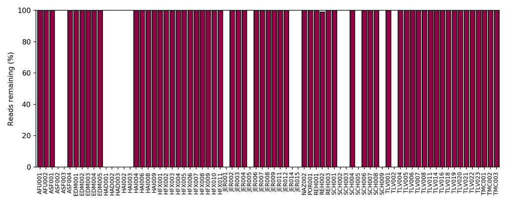

**W12 percent reads kept:**

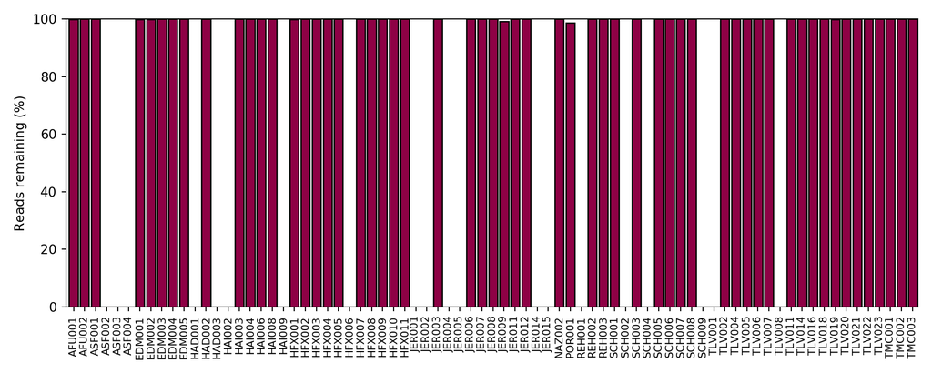

### Kraken2 and Bracken

**Run with RefSeq Complete v93:**

```bash
sudo mount -t ramfs none /scratch/ramdisk/
sudo cp -a /home/shared/Kraken2.0.8_Bracken150mer_RefSeqCompleteV93/ /scratch/ramdisk/
mkdir W0_kraken2_out
mkdir W0_kraken2_kreport
parallel -j 1 'kraken2 --use-names --threads 12 --db /scratch/ramdisk/Kraken2.0.8_Bracken150mer_RefSeqCompleteV93/ --memory-mapping {} --output W0_kraken2_out/{/.}.kraken.txt --report W0_kraken2_kreport/{/.}.kreport --confidence 0.1' ::: W0_decontaminated/*.fastq

parallel -j 1 'bracken -d /scratch/ramdisk/Kraken2.0.8_Bracken150mer_RefSeqCompleteV93/ -i {} -l S -o {.}.bracken -r 150' ::: W0_kraken2_kreport/*.kreport

mkdir W06_kraken2_out
mkdir W06_kraken2_kreport
parallel -j 1 'kraken2 --use-names --threads 12 --db /scratch/ramdisk/Kraken2.0.8_Bracken150mer_RefSeqCompleteV93/ --memory-mapping {} --output W06_kraken2_out/{/.}.kraken.txt --report W06_kraken2_kreport/{/.}.kreport --confidence 0.1' ::: W06_decontaminated/*.fastq

parallel -j 1 'bracken -d /scratch/ramdisk/Kraken2.0.8_Bracken150mer_RefSeqCompleteV93/ -i {} -l S -o {.}.bracken -r 150' ::: W06_kraken2_kreport/*.kreport

mkdir W12_kraken2_out
mkdir W12_kraken2_kreport
parallel -j 1 'kraken2 --use-names --threads 12 --db /scratch/ramdisk/Kraken2.0.8_Bracken150mer_RefSeqCompleteV93/ --memory-mapping {} --output W12_kraken2_out/{/.}.kraken.txt --report W12_kraken2_kreport/{/.}.kreport --confidence 0.1' ::: W12_decontaminated/*.fastq

parallel -j 1 'bracken -d /scratch/ramdisk/Kraken2.0.8_Bracken150mer_RefSeqCompleteV93/ -i {} -l S -o {.}.bracken -r 150' ::: W12_kraken2_kreport/*.kreport
```

**W0 domain level:**

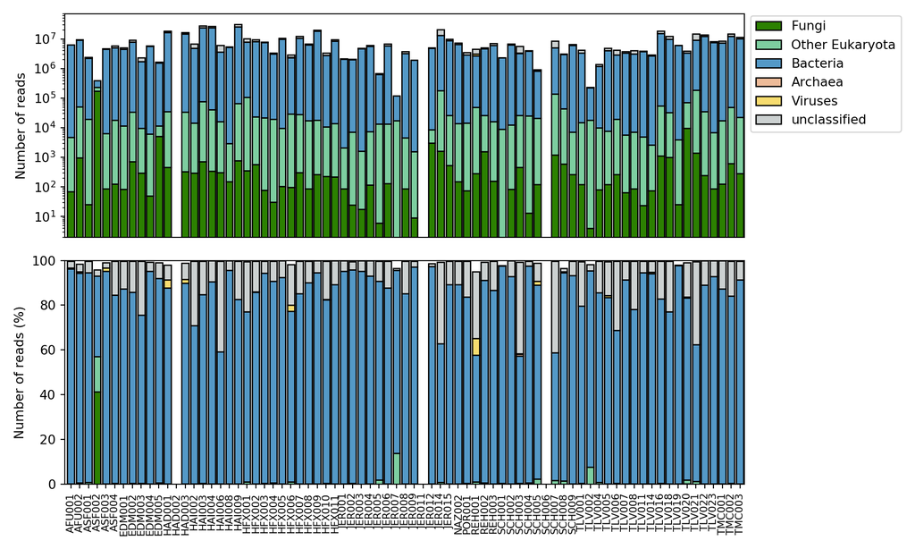

**W06 domain level:**

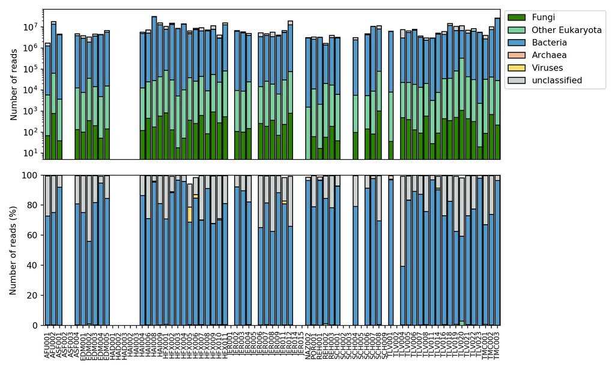

**W12 domain level:**

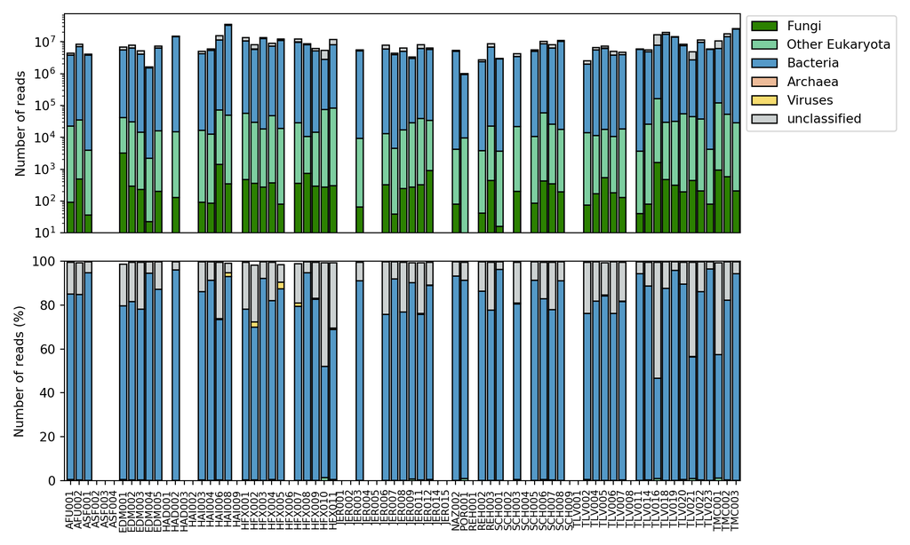

### Get fungal reads

Using [KrakenTools](https://github.com/jenniferlu717/KrakenTools.git) - this searches based on the NCBI fungal taxon ID ([4751](https://www.ncbi.nlm.nih.gov/Taxonomy/Browser/wwwtax.cgi?id=4751&lvl=0)) and then also takes all lower classifications (because we have used the –include-children).

```bash
git clone https://github.com/jenniferlu717/KrakenTools.git

cd W0_kraken2_out
for i in * ; do mv $i ${i%.*} ; done
cd ..
parallel -j 1 'python KrakenTools/extract_kraken_reads.py -k {} -s W0_decontaminated/{/.}.fastq -o W0_fungi/{/.}.fastq -t 4751 --include-children -r W0_kraken2_kreport/{/.}.kreport' ::: W0_kraken2_out/*.kraken

cd W06_kraken2_out
for i in * ; do mv $i ${i%.*} ; done
cd ..
parallel -j 1 'python KrakenTools/extract_kraken_reads.py -k {} -s W06_decontaminated/{/.}.fastq -o W06_fungi/{/.}.fastq -t 4751 --include-children -r W06_kraken2_kreport/{/.}.kreport' ::: W06_kraken2_out/*.kraken

cd W12_kraken2_out
for i in * ; do mv $i ${i%.*} ; done
cd ..
parallel -j 1 'python KrakenTools/extract_kraken_reads.py -k {} -s W12_decontaminated/{/.}.fastq -o W12_fungi/{/.}.fastq -t 4751 --include-children -r W12_kraken2_kreport/{/.}.kreport' ::: W12_kraken2_out/*.kraken
```

### HUMAnN3

**Run using Uniref90 and Uniref50 databases:**

```bash
parallel -j 1 'humann --input {} --output W0_fungi_humann/ --threads 12 --nucleotide-database /home/robyn/databases/humann/humann3_databases/' ::: W0_fungi/*.fastq
```

## Taxonomic analysis

### NMDS plot (all taxa)

This is a NMDS plot using Bray-Curtis distance calculated at the lowest taxonomic classification given by Kraken2 for all taxa present in the sample.

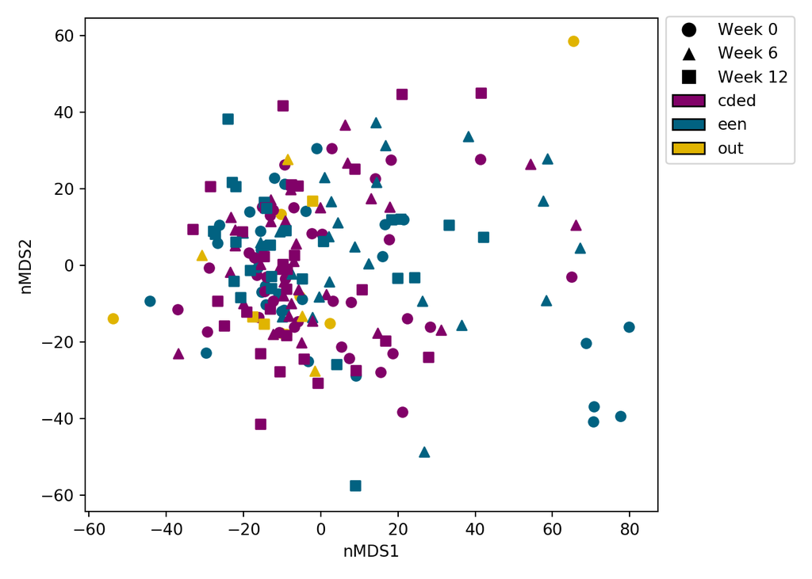

### NMDS plot (fungi only)

This is a NMDS plot using Bray-Curtis distance calculated at the lowest taxonomic classification given by Kraken2 for fungi only.

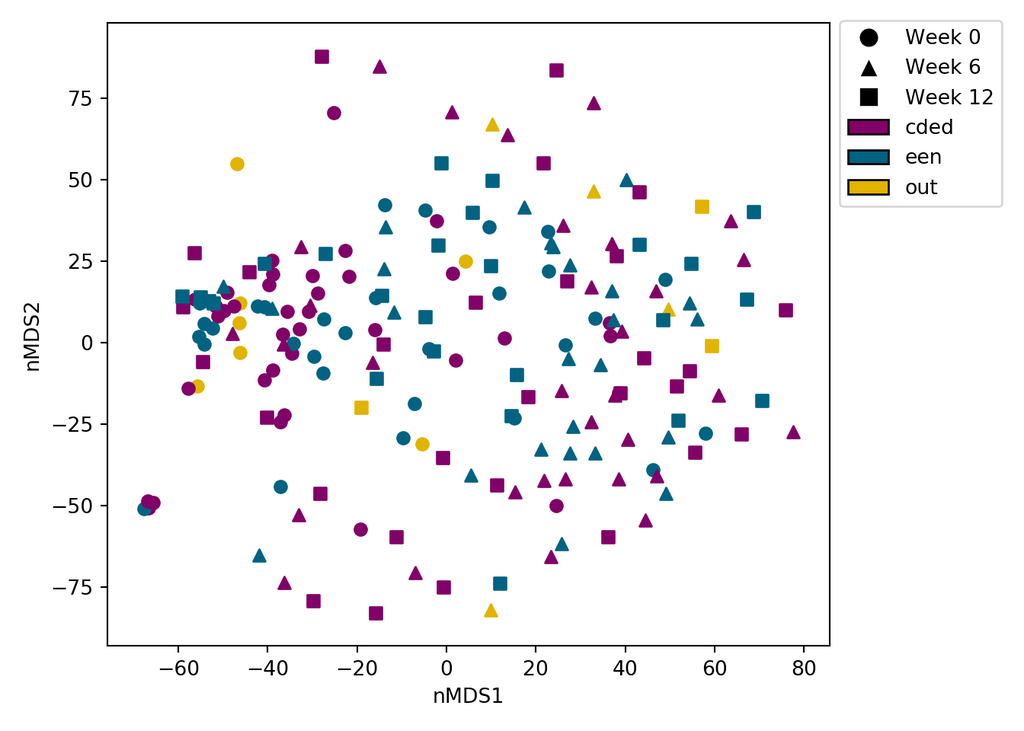

### Stacked bar fungi (genus)

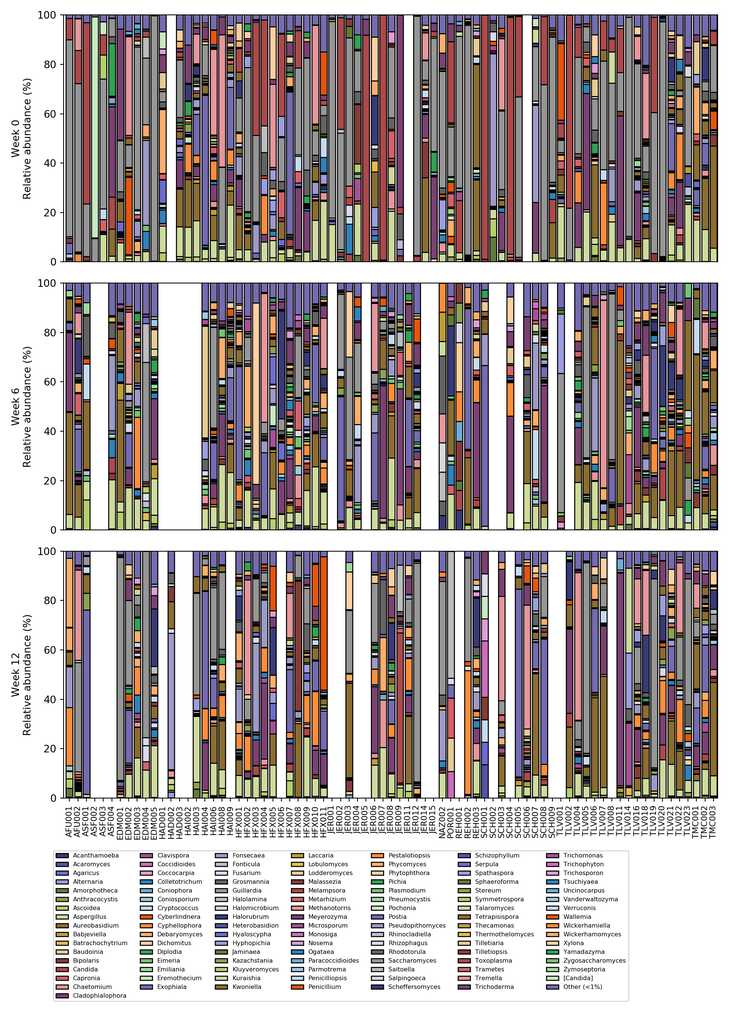